# Course Project

Ross Flieger-Allison

June 21, 2015

# Question

In the provided study (*Velloso, E.; Bulling, A.; Gellersen, H.; Ugulino, W.; Fuks, H. Qualitative Activity Recognition of Weight Lifting Exercises. Proceedings of 4th International Conference in Cooperation with SIGCHI (Augmented Human ’13) . Stuttgart, Germany: ACM SIGCHI, 2013.*), six people participated in a dumbell lifting exercise five different ways. The five ways, as described in the study, were “exactly according to the specification (Class A), throwing the elbows to the front (Class B), lifting the dumbbell only halfway (Class C), lowering the dumbbell only halfway (Class D) and throwing the hips to the front (Class E). Class A corresponds to the specified execution of the exercise, while the other 4 classes correspond to common mistakes.”

By processing data gathered from accelerometers on the belt, forearm, arm, and dumbell of the participants in a machine learning algorithm, our question is: **Can the appropriate activity quality (class A-E) be predicted?**

# Input Data

First, we need to import all the R packages we’re going to use throughout this study.

```r
library(AppliedPredictiveModeling)
library(caret)
library(rattle)
library(rpart.plot)
library(randomForest)
library(e1071)
```

The next step is to import the data and to verify that the training data and the test data are identical.

```r
# Downloads data.
download.file(url = "https://d396qusza40orc.cloudfront.net/predmachlearn/pml-training.csv",
              destfile = "pml-training.csv", method = "curl")
download.file(url="https://d396qusza40orc.cloudfront.net/predmachlearn/pml-testing.csv",
              destfile = "pml-testing.csv", method = "curl")

# Imports the data into R, treating empty values as NA.
pml.training <- read.csv("pml-training.csv", na.strings = c("NA", ""), header = TRUE)
pml.testing <- read.csv("pml-testing.csv", na.strings = c("NA", ""), header = TRUE)

# Verifies that the column names are identical in the training and test set.
all.equal(colnames(pml.training)[1:length(colnames(pml.training)) - 1],
          colnames(pml.testing)[1:length(colnames(pml.training)) - 1])
```

```
## [1] TRUE
```

# Features

Having verified that the schema of both the training and testing sets are identical (excluding the final column representing the A-E class), I decided to eliminate both NA columns and other extraneous columns.

```r
# Counts the number of non-NAs in each col.
non.NAs <- function(x) as.vector(apply(x, 2, function(x) length(which(!is.na(x)))))

# Builds a vector of missing data or NA columns to drop.
col.na.counts <- non.NAs(pml.training)
drops <- c()
for (na in 1:length(col.na.counts)) {
    if (col.na.counts[na] < nrow(pml.training)) {
        drops <- c(drops, colnames(pml.training)[na])
    }
}

# Drops NA data and the first 7 columns as they're unnecessary for predicting.
pml.training <- pml.training[,!(names(pml.training) %in% drops)]
pml.training <- pml.training[,8:length(colnames(pml.training))]
pml.testing <- pml.testing[,!(names(pml.testing) %in% drops)]
pml.testing <- pml.testing[,8:length(colnames(pml.testing))]

# Shows remaining columns.
colnames(pml.training)
```

```
##  [1] "roll_belt"            "pitch_belt"           "yaw_belt"
##  [4] "total_accel_belt"     "gyros_belt_x"         "gyros_belt_y"
##  [7] "gyros_belt_z"         "accel_belt_x"         "accel_belt_y"
## [10] "accel_belt_z"         "magnet_belt_x"        "magnet_belt_y"
## [13] "magnet_belt_z"        "roll_arm"             "pitch_arm"
## [16] "yaw_arm"              "total_accel_arm"      "gyros_arm_x"
## [19] "gyros_arm_y"          "gyros_arm_z"          "accel_arm_x"
## [22] "accel_arm_y"          "accel_arm_z"          "magnet_arm_x"
## [25] "magnet_arm_y"         "magnet_arm_z"         "roll_dumbbell"
## [28] "pitch_dumbbell"       "yaw_dumbbell"         "total_accel_dumbbell"
## [31] "gyros_dumbbell_x"     "gyros_dumbbell_y"     "gyros_dumbbell_z"
## [34] "accel_dumbbell_x"     "accel_dumbbell_y"     "accel_dumbbell_z"
## [37] "magnet_dumbbell_x"    "magnet_dumbbell_y"    "magnet_dumbbell_z"
## [40] "roll_forearm"         "pitch_forearm"        "yaw_forearm"
## [43] "total_accel_forearm"  "gyros_forearm_x"      "gyros_forearm_y"
## [46] "gyros_forearm_z"      "accel_forearm_x"      "accel_forearm_y"
## [49] "accel_forearm_z"      "magnet_forearm_x"     "magnet_forearm_y"
## [52] "magnet_forearm_z"     "classe"
```

```r
colnames(pml.testing)
```

```
##  [1] "roll_belt"            "pitch_belt"           "yaw_belt"
##  [4] "total_accel_belt"     "gyros_belt_x"         "gyros_belt_y"
##  [7] "gyros_belt_z"         "accel_belt_x"         "accel_belt_y"
## [10] "accel_belt_z"         "magnet_belt_x"        "magnet_belt_y"
## [13] "magnet_belt_z"        "roll_arm"             "pitch_arm"
## [16] "yaw_arm"              "total_accel_arm"      "gyros_arm_x"
## [19] "gyros_arm_y"          "gyros_arm_z"          "accel_arm_x"
## [22] "accel_arm_y"          "accel_arm_z"          "magnet_arm_x"
## [25] "magnet_arm_y"         "magnet_arm_z"         "roll_dumbbell"
## [28] "pitch_dumbbell"       "yaw_dumbbell"         "total_accel_dumbbell"
## [31] "gyros_dumbbell_x"     "gyros_dumbbell_y"     "gyros_dumbbell_z"
## [34] "accel_dumbbell_x"     "accel_dumbbell_y"     "accel_dumbbell_z"
## [37] "magnet_dumbbell_x"    "magnet_dumbbell_y"    "magnet_dumbbell_z"
## [40] "roll_forearm"         "pitch_forearm"        "yaw_forearm"
## [43] "total_accel_forearm"  "gyros_forearm_x"      "gyros_forearm_y"
## [46] "gyros_forearm_z"      "accel_forearm_x"      "accel_forearm_y"
## [49] "accel_forearm_z"      "magnet_forearm_x"     "magnet_forearm_y"
## [52] "magnet_forearm_z"     "problem_id"
```

Now, let’s check for covariates that have virtually no variablility.

```r
nearZeroVar(pml.training, saveMetrics = TRUE)
```

```
##                      freqRatio percentUnique zeroVar   nzv
## roll_belt             1.101904     6.7781062   FALSE FALSE
## pitch_belt            1.036082     9.3772296   FALSE FALSE
## yaw_belt              1.058480     9.9734991   FALSE FALSE
## total_accel_belt      1.063160     0.1477933   FALSE FALSE
## gyros_belt_x          1.058651     0.7134849   FALSE FALSE
## gyros_belt_y          1.144000     0.3516461   FALSE FALSE
## gyros_belt_z          1.066214     0.8612782   FALSE FALSE
## accel_belt_x          1.055412     0.8357966   FALSE FALSE
## accel_belt_y          1.113725     0.7287738   FALSE FALSE
## accel_belt_z          1.078767     1.5237998   FALSE FALSE
## magnet_belt_x         1.090141     1.6664968   FALSE FALSE
## magnet_belt_y         1.099688     1.5187035   FALSE FALSE
## magnet_belt_z         1.006369     2.3290184   FALSE FALSE
## roll_arm             52.338462    13.5256345   FALSE FALSE
## pitch_arm            87.256410    15.7323412   FALSE FALSE
## yaw_arm              33.029126    14.6570176   FALSE FALSE
## total_accel_arm       1.024526     0.3363572   FALSE FALSE
## gyros_arm_x           1.015504     3.2769341   FALSE FALSE
## gyros_arm_y           1.454369     1.9162165   FALSE FALSE
## gyros_arm_z           1.110687     1.2638875   FALSE FALSE
## accel_arm_x           1.017341     3.9598410   FALSE FALSE
## accel_arm_y           1.140187     2.7367241   FALSE FALSE
## accel_arm_z           1.128000     4.0362858   FALSE FALSE
## magnet_arm_x          1.000000     6.8239731   FALSE FALSE
## magnet_arm_y          1.056818     4.4439914   FALSE FALSE
## magnet_arm_z          1.036364     6.4468454   FALSE FALSE
## roll_dumbbell         1.022388    84.2065029   FALSE FALSE
## pitch_dumbbell        2.277372    81.7449801   FALSE FALSE
## yaw_dumbbell          1.132231    83.4828254   FALSE FALSE
## total_accel_dumbbell  1.072634     0.2191418   FALSE FALSE
## gyros_dumbbell_x      1.003268     1.2282132   FALSE FALSE
## gyros_dumbbell_y      1.264957     1.4167771   FALSE FALSE
## gyros_dumbbell_z      1.060100     1.0498420   FALSE FALSE
## accel_dumbbell_x      1.018018     2.1659362   FALSE FALSE
## accel_dumbbell_y      1.053061     2.3748853   FALSE FALSE
## accel_dumbbell_z      1.133333     2.0894914   FALSE FALSE
## magnet_dumbbell_x     1.098266     5.7486495   FALSE FALSE
## magnet_dumbbell_y     1.197740     4.3012945   FALSE FALSE
## magnet_dumbbell_z     1.020833     3.4451126   FALSE FALSE
## roll_forearm         11.589286    11.0895933   FALSE FALSE
## pitch_forearm        65.983051    14.8557741   FALSE FALSE
## yaw_forearm          15.322835    10.1467740   FALSE FALSE
## total_accel_forearm   1.128928     0.3567424   FALSE FALSE
## gyros_forearm_x       1.059273     1.5187035   FALSE FALSE
## gyros_forearm_y       1.036554     3.7763735   FALSE FALSE
## gyros_forearm_z       1.122917     1.5645704   FALSE FALSE
## accel_forearm_x       1.126437     4.0464784   FALSE FALSE
## accel_forearm_y       1.059406     5.1116094   FALSE FALSE
## accel_forearm_z       1.006250     2.9558659   FALSE FALSE
## magnet_forearm_x      1.012346     7.7667924   FALSE FALSE
## magnet_forearm_y      1.246914     9.5403119   FALSE FALSE
## magnet_forearm_z      1.000000     8.5771073   FALSE FALSE
## classe                1.469581     0.0254816   FALSE FALSE
```

Given that all of the near zero variance variables are FALSE, there’s no need to eliminate any covariates due to lack of variablility.

# Algorithm

We were provided with a large training set (19,622 entries) and a small testing set (20 entries). Instead of performing the algorithm on the entire training set, which would be time consuming and wouldn’t allow for an attempt on a testing set, I chose to divide the given training set into four roughly equal sets, each of which was then split into a training set (comprising 60% of the entries) and a testing set (comprising 40% of the entries).

```r
# Divides the given training set into 4 roughly equal sets.
set.seed(666)
ids.small <- createDataPartition(y = pml.training$classe, p = 0.25, list = FALSE)
pml.small1 <- pml.training[ids.small,]
pml.remainder <- pml.training[-ids.small,]
set.seed(666)
ids.small <- createDataPartition(y = pml.remainder$classe, p = 0.33, list = FALSE)
pml.small2 <- pml.remainder[ids.small,]
pml.remainder <- pml.remainder[-ids.small,]
set.seed(666)
ids.small <- createDataPartition(y = pml.remainder$classe, p = 0.5, list = FALSE)
pml.small3 <- pml.remainder[ids.small,]
pml.small4 <- pml.remainder[-ids.small,]

# Divides each of these 4 sets into training (60%) and test (40%) sets.
set.seed(666)
in.train <- createDataPartition(y = pml.small1$classe, p = 0.6, list = FALSE)
pml.small.training1 <- pml.small1[in.train,]
pml.small.testing1 <- pml.small1[-in.train,]
set.seed(666)
in.train <- createDataPartition(y = pml.small2$classe, p = 0.6, list = FALSE)
pml.small.training2 <- pml.small2[in.train,]
pml.small.testing2 <- pml.small2[-in.train,]
set.seed(666)
in.train <- createDataPartition(y = pml.small3$classe, p = 0.6, list = FALSE)
pml.small.training3 <- pml.small3[in.train,]
pml.small.testing3 <- pml.small3[-in.train,]
set.seed(666)
in.train <- createDataPartition(y = pml.small4$classe, p = 0.6, list = FALSE)
pml.small.training4 <- pml.small4[in.train,]
pml.small.testing4 <- pml.small4[-in.train,]
```

Based on both the process outlined in Section 5.2 of the aforementioned paper and the concensus in the Coursera discussion forums, I chose two different algorithms via the caret package: classification trees (method = rpart) and random forests (method = rf).

# Parameters

I decided to try classification trees initially and then introduce preprocessing and cross validation later.

# Evaluation

First, the classification tree:

```r
# Trains on training set 1 of 4 with no extra features.
set.seed(666)
mod.fit <- train(pml.small.training1$classe ~ ., data = pml.small.training1,
                 method = "rpart")
print(mod.fit, digits = 3)
```

```
## CART
##
## 2946 samples
##   52 predictor
##    5 classes: 'A', 'B', 'C', 'D', 'E'
##
## No pre-processing
## Resampling: Bootstrapped (25 reps)
##
## Summary of sample sizes: 2946, 2946, 2946, 2946, 2946, 2946, ...
##
## Resampling results across tuning parameters:
##
##   cp      Accuracy  Kappa   Accuracy SD  Kappa SD
##   0.0346  0.531     0.4003  0.0355       0.0479
##   0.0442  0.471     0.3076  0.0555       0.0967
##   0.1162  0.324     0.0602  0.0456       0.0641
##
## Accuracy was used to select the optimal model using  the largest value.
## The final value used for the model was cp = 0.0346.
```

```r
print(mod.fit$finalModel, digits=3)
```

```
## n= 2946
##
## node), split, n, loss, yval, (yprob)
##       * denotes terminal node
##
##   1) root 2946 2110 A (0.28 0.19 0.17 0.16 0.18)
##     2) roll_belt< 130 2699 1860 A (0.31 0.21 0.19 0.18 0.11)
##       4) pitch_forearm< -34 220    0 A (1 0 0 0 0) *
##       5) pitch_forearm>=-34 2479 1860 A (0.25 0.23 0.21 0.19 0.12)
##        10) yaw_belt>=168 138   15 A (0.89 0.072 0 0.036 0) *
##        11) yaw_belt< 168 2341 1780 B (0.21 0.24 0.22 0.2 0.13)
##          22) magnet_dumbbell_z< -83.5 305  134 A (0.56 0.3 0.046 0.069 0.02) *
##          23) magnet_dumbbell_z>=-83.5 2036 1540 C (0.16 0.23 0.25 0.22 0.14)
##            46) roll_dumbbell< 57.7 1209  776 C (0.18 0.19 0.36 0.16 0.11) *
##            47) roll_dumbbell>=57.7 827  565 D (0.12 0.29 0.081 0.32 0.19)
##              94) magnet_belt_y>=590 687  433 D (0.11 0.35 0.07 0.37 0.1)
##               188) total_accel_dumbbell>=5.5 474  260 B (0.097 0.45 0.1 0.22 0.13) *
##               189) total_accel_dumbbell< 5.5 213   62 D (0.14 0.11 0 0.71 0.042) *
##              95) magnet_belt_y< 590 140   55 E (0.19 0.014 0.14 0.057 0.61) *
##     3) roll_belt>=130 247    1 E (0.004 0 0 0 1) *
```

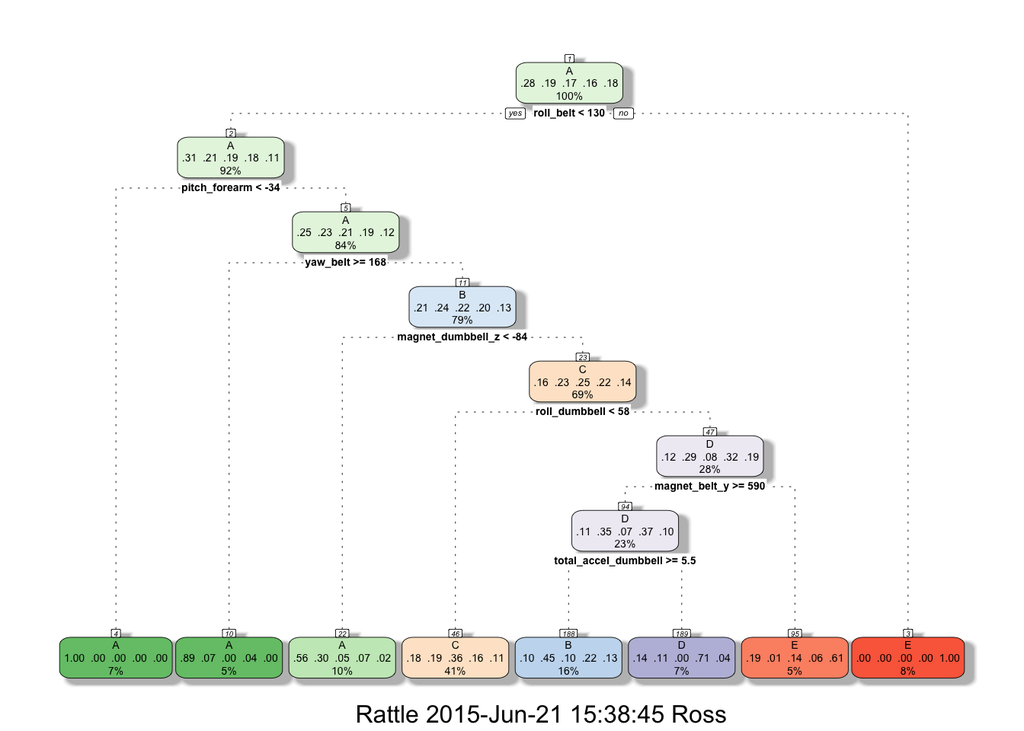

```r
fancyRpartPlot(mod.fit$finalModel)
```

```r
# Runs against testing set 1 of 4 with no extra features.
predictions <- predict(mod.fit, newdata = pml.small.testing1)
print(confusionMatrix(predictions, pml.small.testing1$classe), digits = 4)
```

```
## Confusion Matrix and Statistics
##
##           Reference
## Prediction   A   B   C   D   E
##          A 368  74  11  28   8
##          B  24 151  25  83  30
##          C 135 148 288 138  99
##          D  15   7   0  69   4
##          E  16   0  18   3 219
##
## Overall Statistics
##
##                Accuracy : 0.5584
##                  95% CI : (0.5361, 0.5805)
##     No Information Rate : 0.2845
##     P-Value [Acc > NIR] : < 2.2e-16
##
##                   Kappa : 0.4441
##  Mcnemar's Test P-Value : < 2.2e-16
##
## Statistics by Class:
##
##                      Class: A Class: B Class: C Class: D Class: E
## Sensitivity            0.6595   0.3974   0.8421  0.21495   0.6083
## Specificity            0.9138   0.8975   0.6788  0.98415   0.9769
## Pos Pred Value         0.7526   0.4824   0.3564  0.72632   0.8555
## Neg Pred Value         0.8709   0.8610   0.9532  0.86495   0.9173
## Prevalence             0.2845   0.1938   0.1744  0.16369   0.1836
## Detection Rate         0.1877   0.0770   0.1469  0.03519   0.1117
## Detection Prevalence   0.2494   0.1596   0.4120  0.04844   0.1305
## Balanced Accuracy      0.7866   0.6475   0.7605  0.59955   0.7926
```

I was disappointed by the low accuracy rate (0.5584) and hoped for significant improvement by incorporating preprocessing and/or cross validation.

```r
# Trains on training set 1 of 4 with only preprocessing.
set.seed(666)
mod.fit <- train(pml.small.training1$classe ~ .,
                 preProcess = c("center", "scale"),
                 data = pml.small.training1,
                 method = "rpart")
print(mod.fit, digits = 3)
```

```
## CART
##
## 2946 samples
##   52 predictor
##    5 classes: 'A', 'B', 'C', 'D', 'E'
##
## Pre-processing: centered, scaled
## Resampling: Bootstrapped (25 reps)
##
## Summary of sample sizes: 2946, 2946, 2946, 2946, 2946, 2946, ...
##
## Resampling results across tuning parameters:
##
##   cp      Accuracy  Kappa   Accuracy SD  Kappa SD
##   0.0346  0.531     0.4003  0.0355       0.0479
##   0.0442  0.471     0.3077  0.0555       0.0968
##   0.1162  0.324     0.0602  0.0456       0.0641
##
## Accuracy was used to select the optimal model using  the largest value.
## The final value used for the model was cp = 0.0346.
```

```r
# Trains on training set 1 of 4 with only cross validation.
set.seed(666)
mod.fit <- train(pml.small.training1$classe ~ .,
                 trControl = trainControl(method = "cv", number = 4),
                 data = pml.small.training1,
                 method = "rpart")
print(mod.fit, digits = 3)
```

```
## CART
##
## 2946 samples
##   52 predictor
##    5 classes: 'A', 'B', 'C', 'D', 'E'
##
## No pre-processing
## Resampling: Cross-Validated (4 fold)
##
## Summary of sample sizes: 2212, 2209, 2208, 2209
##
## Resampling results across tuning parameters:
##
##   cp      Accuracy  Kappa   Accuracy SD  Kappa SD
##   0.0346  0.552     0.4266  0.0383       0.0542
##   0.0442  0.470     0.3041  0.0689       0.1197
##   0.1162  0.344     0.0914  0.0405       0.0610
##
## Accuracy was used to select the optimal model using  the largest value.
## The final value used for the model was cp = 0.0346.
```

```r
# Trains on training set 1 of 4 with both preprocessing and cross validation.
set.seed(666)
mod.fit <- train(pml.small.training1$classe ~ .,
                 preProcess = c("center", "scale"),
                 trControl = trainControl(method = "cv", number = 4),
                 data = pml.small.training1,
                 method = "rpart")
print(mod.fit, digits = 3)
```

```
## CART
##
## 2946 samples
##   52 predictor
##    5 classes: 'A', 'B', 'C', 'D', 'E'
##
## Pre-processing: centered, scaled
## Resampling: Cross-Validated (4 fold)
##
## Summary of sample sizes: 2212, 2209, 2208, 2209
##
## Resampling results across tuning parameters:
##
##   cp      Accuracy  Kappa   Accuracy SD  Kappa SD
##   0.0346  0.552     0.4266  0.0383       0.0542
##   0.0442  0.470     0.3041  0.0689       0.1197
##   0.1162  0.344     0.0914  0.0405       0.0610
##
## Accuracy was used to select the optimal model using  the largest value.
## The final value used for the model was cp = 0.0346.
```

```r
# Runs against testing set 1 of 4 with both preprocessing and cross validation.
predictions <- predict(mod.fit, newdata = pml.small.testing1)
print(confusionMatrix(predictions, pml.small.testing1$classe), digits = 4)
```

```
## Confusion Matrix and Statistics
##
##           Reference
## Prediction   A   B   C   D   E
##          A 368  74  11  28   8
##          B  24 151  25  83  30
##          C 135 148 288 138  99
##          D  15   7   0  69   4
##          E  16   0  18   3 219
##
## Overall Statistics
##
##                Accuracy : 0.5584
##                  95% CI : (0.5361, 0.5805)
##     No Information Rate : 0.2845
##     P-Value [Acc > NIR] : < 2.2e-16
##
##                   Kappa : 0.4441
##  Mcnemar's Test P-Value : < 2.2e-16
##
## Statistics by Class:
##
##                      Class: A Class: B Class: C Class: D Class: E
## Sensitivity            0.6595   0.3974   0.8421  0.21495   0.6083
## Specificity            0.9138   0.8975   0.6788  0.98415   0.9769
## Pos Pred Value         0.7526   0.4824   0.3564  0.72632   0.8555
## Neg Pred Value         0.8709   0.8610   0.9532  0.86495   0.9173
## Prevalence             0.2845   0.1938   0.1744  0.16369   0.1836
## Detection Rate         0.1877   0.0770   0.1469  0.03519   0.1117
## Detection Prevalence   0.2494   0.1596   0.4120  0.04844   0.1305
## Balanced Accuracy      0.7866   0.6475   0.7605  0.59955   0.7926
```

The impact of incorporating both preprocessing and cross validation appeared to show some minimal improvement (accuracy rate rose from 0.531 to 0.552 against training sets). However, when run against the corresponding testing set, the accuracy rate was identical (0.5584) for both the “out of the box” and the preprocessing/cross validation methods.

Next, I decided to use a random forest.

I first assessed the impact/value of including preprocessing.

```r
# Trains on training set 1 of 4 with only cross validation.
set.seed(666)
mod.fit <- train(pml.small.training1$classe ~ .,
                 method = "rf",
                 trControl = trainControl(method = "cv", number = 4),
                 data = pml.small.training1)
print(mod.fit, digits = 3)
```

```
## Random Forest
##
## 2946 samples
##   52 predictor
##    5 classes: 'A', 'B', 'C', 'D', 'E'
##
## No pre-processing
## Resampling: Cross-Validated (4 fold)
##
## Summary of sample sizes: 2212, 2209, 2208, 2209
##
## Resampling results across tuning parameters:
##
##   mtry  Accuracy  Kappa  Accuracy SD  Kappa SD
##    2    0.951     0.939  0.00291      0.00367
##   27    0.957     0.945  0.00740      0.00937
##   52    0.951     0.939  0.01226      0.01549
##
## Accuracy was used to select the optimal model using  the largest value.
## The final value used for the model was mtry = 27.
```

```r
# Runs against testing set 1 of 4.
predictions <- predict(mod.fit, newdata = pml.small.testing1)
print(confusionMatrix(predictions, pml.small.testing1$classe), digits = 4)
```

```
## Confusion Matrix and Statistics
##
##           Reference
## Prediction   A   B   C   D   E
##          A 556  10   1   0   0
##          B   2 360  13   0   2
##          C   0   9 323   4   5
##          D   0   1   5 313   2
##          E   0   0   0   4 351
##
## Overall Statistics
##
##                Accuracy : 0.9704
##                  95% CI : (0.9619, 0.9775)
##     No Information Rate : 0.2845
##     P-Value [Acc > NIR] : < 2.2e-16
##
##                   Kappa : 0.9626
##  Mcnemar's Test P-Value : NA
##
## Statistics by Class:
##
##                      Class: A Class: B Class: C Class: D Class: E
## Sensitivity            0.9964   0.9474   0.9444   0.9751   0.9750
## Specificity            0.9922   0.9892   0.9889   0.9951   0.9975
## Pos Pred Value         0.9806   0.9549   0.9472   0.9751   0.9887
## Neg Pred Value         0.9986   0.9874   0.9883   0.9951   0.9944
## Prevalence             0.2845   0.1938   0.1744   0.1637   0.1836
## Detection Rate         0.2835   0.1836   0.1647   0.1596   0.1790
## Detection Prevalence   0.2891   0.1922   0.1739   0.1637   0.1810
## Balanced Accuracy      0.9943   0.9683   0.9667   0.9851   0.9863
```

```r
# Run against 20 testing set.
print(predict(mod.fit, newdata = pml.testing))
```

```
##  [1] B A A A A E D B A A B C B A E E A B B B
## Levels: A B C D E
```

```r
# Trains on training set 1 of 4 with only both preprocessing and cross validation.
set.seed(666)
mod.fit <- train(pml.small.training1$classe ~ .,
                 method = "rf",
                 preProcess = c("center", "scale"),
                 trControl = trainControl(method = "cv", number = 4),
                 data = pml.small.training1)
print(mod.fit, digits=3)
```

```
## Random Forest
##
## 2946 samples
##   52 predictor
##    5 classes: 'A', 'B', 'C', 'D', 'E'
##
## Pre-processing: centered, scaled
## Resampling: Cross-Validated (4 fold)
##
## Summary of sample sizes: 2212, 2209, 2208, 2209
##
## Resampling results across tuning parameters:
##
##   mtry  Accuracy  Kappa  Accuracy SD  Kappa SD
##    2    0.951     0.939  0.00172      0.00217
##   27    0.955     0.943  0.00588      0.00743
##   52    0.952     0.939  0.01061      0.01341
##
## Accuracy was used to select the optimal model using  the largest value.
## The final value used for the model was mtry = 27.
```

```r
# Runs against testing set 1 of 4.
predictions <- predict(mod.fit, newdata = pml.small.testing1)
print(confusionMatrix(predictions, pml.small.testing1$classe), digits = 4)
```

```
## Confusion Matrix and Statistics
##
##           Reference
## Prediction   A   B   C   D   E
##          A 556  12   1   0   1
##          B   2 358  12   0   0
##          C   0   9 324   6   5
##          D   0   1   5 310   2
##          E   0   0   0   5 352
##
## Overall Statistics
##
##                Accuracy : 0.9689
##                  95% CI : (0.9602, 0.9761)
##     No Information Rate : 0.2845
##     P-Value [Acc > NIR] : < 2.2e-16
##
##                   Kappa : 0.9606
##  Mcnemar's Test P-Value : NA
##
## Statistics by Class:
##
##                      Class: A Class: B Class: C Class: D Class: E
## Sensitivity            0.9964   0.9421   0.9474   0.9657   0.9778
## Specificity            0.9900   0.9911   0.9876   0.9951   0.9969
## Pos Pred Value         0.9754   0.9624   0.9419   0.9748   0.9860
## Neg Pred Value         0.9986   0.9862   0.9889   0.9933   0.9950
## Prevalence             0.2845   0.1938   0.1744   0.1637   0.1836
## Detection Rate         0.2835   0.1826   0.1652   0.1581   0.1795
## Detection Prevalence   0.2907   0.1897   0.1754   0.1622   0.1820
## Balanced Accuracy      0.9932   0.9666   0.9675   0.9804   0.9873
```